# Capstone Project UoM-MSE-IE

Andre Luiz Cunha

2020-10-11

# 1 Exploratory Analysis

## 1.1 Dataset

The dataset was obtained at [City of Melbourne - Pedestrian Counting System](http://www.pedestrian.melbourne.vic.gov.au/). The data is from pedestrian counting system (loop sensor) and it contains hourly counts from 2009 to 2019. The main idea is to explore these data and figure out some spatio-temporal relationship between sensors, and detect events automatically.

In this example was used only the year of 2019.

```r
## Filenames
datafile = "../data/rawsample2019.csv"
#datafile = "../data/pedestrian_counts_2009-2019.csv"
posfile = "../data/sensor_locations.csv"

## Upload CSV files
csv.data <- read.csv(datafile, header = TRUE, sep = ",")
csv.pos <- read.csv(posfile, header = TRUE, sep=",")

## Create dataset
db <- merge(csv.data, csv.pos, by.x = "Sensor_ID", by.y="sensor_id")

## Create a tibble dataset
  pedata <- tibble(
    id = db$ID,
    sensorID = db$Sensor_ID,
    sensorName = db$Sensor_Name,
    count = db$Hourly_Counts,
    lat = db$latitude,
    long = db$longitude
  ) %>%
    mutate( datetime = make_datetime(
      year = db$Year,
      month = match(db$Month,month.name),
      day = db$Mdate,
      hour = db$Time),
    )

## Filter year 2019
ped.year <- pedata %>%
  filter(year(datetime) == params$year) %>%
  arrange(sensorID, datetime)

rm(list=c("csv.data", "csv.pos", "db", "pedata"))
ped.year
```

```
## # A tibble: 456,829 x 7
##         id sensorID sensorName             count   lat  long datetime
##      <int>    <int> <chr>                  <int> <dbl> <dbl> <dttm>
##  1 2510010        1 Bourke Street Mall (N~   918 -37.8  145. 2019-01-01 00:00:00
##  2 2510059        1 Bourke Street Mall (N~   995 -37.8  145. 2019-01-01 01:00:00
##  3 2510108        1 Bourke Street Mall (N~   416 -37.8  145. 2019-01-01 02:00:00
##  4 2510157        1 Bourke Street Mall (N~   382 -37.8  145. 2019-01-01 03:00:00
##  5 2510206        1 Bourke Street Mall (N~   165 -37.8  145. 2019-01-01 04:00:00
##  6 2510255        1 Bourke Street Mall (N~   117 -37.8  145. 2019-01-01 05:00:00
##  7 2510304        1 Bourke Street Mall (N~    48 -37.8  145. 2019-01-01 06:00:00
##  8 2510353        1 Bourke Street Mall (N~    47 -37.8  145. 2019-01-01 07:00:00
##  9 2510402        1 Bourke Street Mall (N~    86 -37.8  145. 2019-01-01 08:00:00
## 10 2510451        1 Bourke Street Mall (N~   253 -37.8  145. 2019-01-01 09:00:00
## # ... with 456,819 more rows
```

```r
## Select the variables
df <- ped.year %>%
  group_by(sensorID, lat, long) %>%
  summarise(hour.year = n()/(24*yday(make_date(params$year,12,31))),
            count.total = sum(count), count.mean = mean(count)) %>%
  mutate(content=paste(sep=";",
                       paste0("ID: ", sensorID),
                       paste0("%YEAR: ", round(hour.year,2)),
                       paste0("AVG: ",round(count.mean,2))))
```

```r
## Plot map
pal <- colorNumeric(
  palette = "viridis",
  domain = df$count.mean
)

leaflet(df) %>%
  fitBounds(~min(long), ~min(lat), ~max(long), ~max(lat)) %>%
  addCircles(lng = ~long, lat = ~lat, weight = 1, radius = ~sqrt(count.mean)*3,
             label = ~content, color = ~pal(count.mean)) %>%
  addLegend(pal=pal, values = ~count.mean) %>%
  #addProviderTiles(providers$Stamen.Toner)
  addProviderTiles(providers$CartoDB.Positron)
```

[interactive chart not shown]

```r
  #addProviderTiles(providers$Esri.NatGeoWorldMap)
```

## 1.2 Time-based analysis

Selecting the sensor by ID, two figures depict the all data recorded in the period and the heatmap considering ‘hour’ and ‘day’.

```r
# ## Select sensor ID
# sensorids <- unique(ped.year$sensorID)
# selectInput("id_sensors", label = "Sensor ID:",
#               choices = sensorids)
#
# ## Filter dataset by sensorID selected
# df1sensor <- ped.year %>%
#   select(sensorID, datetime, count) %>%
#   mutate(year=year(datetime),
#          month=month(datetime, label=TRUE),
#          day=day(datetime),
#          hour=hour(datetime))
#
# df1sensor <- reactive({
#   df1sensor %>% filter(sensorID == input$id_sensors)
# })
#
# ## Plot timeline
# renderPlot({
#   df1sensor %>% filter(sensorID == input$id_sensors) %>%
#   ggplot(aes(x=datetime, y=count)) + geom_line()
# })
#
# ## Plot heatmap
# renderPlot({
#   p <- ggplot(df1sensor %>% filter(sensorID == 1), #input$id_sensors),
#               aes(day, hour, fill=count)) +
#     geom_tile(color="white", size=0.1) +
#     scale_fill_viridis("Hourly Count", option = "C")
#   p <-p + facet_grid(month)
#   p <-p + scale_y_continuous(trans = "reverse", breaks = unique(df1sensor$hour))
#   p <-p + scale_x_continuous(breaks =c(1,10,20,31))
#   p <-p + theme_minimal(base_size = 8)
#   p <-p + labs(title="Project", x="Day", y="Hour Commencing")
#   p <-p + theme(legend.position = "bottom")+
#   theme(plot.title=element_text(size = 14))+
#   theme(axis.text.y=element_text(size=6)) +
#   theme(strip.background = element_rect(colour="white"))+
#   theme(plot.title=element_text(hjust=0))+
#   theme(axis.ticks=element_blank())+
#   theme(axis.text=element_text(size=7))+
#   theme(legend.title=element_text(size=8))+
#   theme(legend.text=element_text(size=6))
# })
```

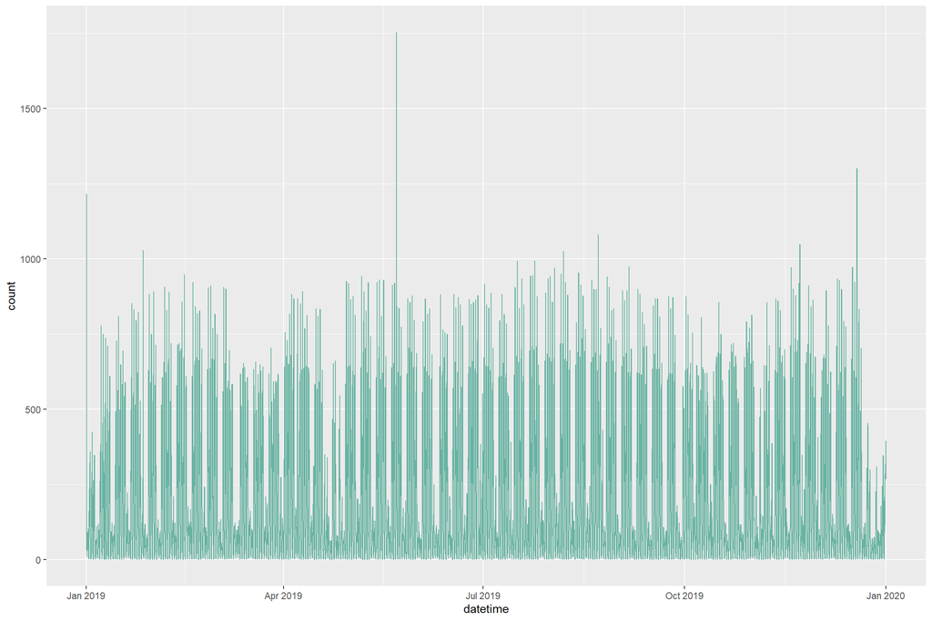

```r
## Filter dataset by sensorID selected
df1sensor <- ped.year %>%
  select(sensorID, datetime, count) %>%
  filter(sensorID == params$ids) %>%
  mutate(year=year(datetime),
         month=month(datetime, label=TRUE),
         day=day(datetime),
         hour=hour(datetime))

## Plot timeseries
df1sensor %>%
  ggplot(aes(datetime,count)) +
    geom_line(color="#69b3a2")
```

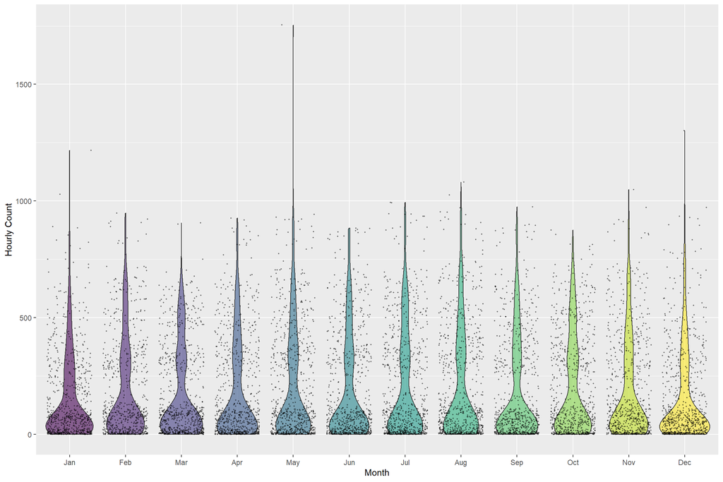

```r
## Plot boxplot
df1sensor %>%
  ggplot(aes(x=month, y=count, fill=month)) +
  #geom_boxplot(coef = 1.5, outlier.color = "red", outlier.size = 1) +
  geom_violin() +
  scale_fill_viridis(discrete = TRUE, alpha=0.6) +
  geom_jitter(color="black", size=0.4, alpha = 0.4) +
  theme(
    legend.position = "none"
  ) +
  xlab("Month") + ylab("Hourly Count")
```

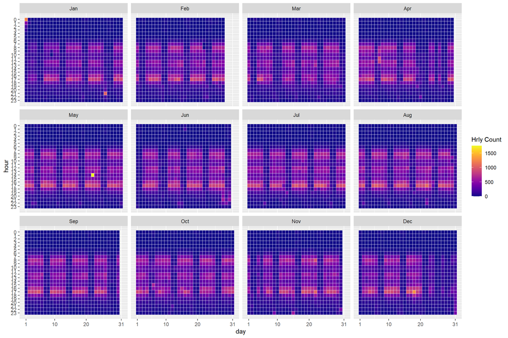

```r
## Plot heatmap
df1sensor %>%
  ggplot(aes(x=day,y=hour,fill=count)) +
  geom_tile(color="white", size=0.1) +
  scale_fill_viridis(name="Hrly Count" ,option ="C") +
  facet_wrap(~month) +
  scale_y_continuous(trans = "reverse", breaks = unique(df1sensor$hour)) +
  scale_x_continuous(breaks =c(1,10,20,31))
```

### 1.2.1 Time resolution

As the dataset brings hourly counts, each level of the Wavelet coefficients represent an data aggregation on power of 2 ($2^n$). To understand that, each level represents:

```r
n.levels = 15
for(i in 1:n.levels) {
  hours <- 2^i
  print(paste0("Level: ", i, " -> ", floor(hours/(30*24)), " months, ", floor((hours%%(24*30))/24), " days, ", (hours%%24), " hours"))
}
```

```
## [1] "Level: 1 -> 0 months, 0 days, 2 hours"
## [1] "Level: 2 -> 0 months, 0 days, 4 hours"
## [1] "Level: 3 -> 0 months, 0 days, 8 hours"
## [1] "Level: 4 -> 0 months, 0 days, 16 hours"
## [1] "Level: 5 -> 0 months, 1 days, 8 hours"
## [1] "Level: 6 -> 0 months, 2 days, 16 hours"
## [1] "Level: 7 -> 0 months, 5 days, 8 hours"
## [1] "Level: 8 -> 0 months, 10 days, 16 hours"
## [1] "Level: 9 -> 0 months, 21 days, 8 hours"
## [1] "Level: 10 -> 1 months, 12 days, 16 hours"
## [1] "Level: 11 -> 2 months, 25 days, 8 hours"
## [1] "Level: 12 -> 5 months, 20 days, 16 hours"
## [1] "Level: 13 -> 11 months, 11 days, 8 hours"
## [1] "Level: 14 -> 22 months, 22 days, 16 hours"
## [1] "Level: 15 -> 45 months, 15 days, 8 hours"
```

The level 3 is an interesting point because it is possible to analyse the data in 3 periods of 8 hours (morning, afternoon, night). The level 7 represent almost one working week, however the problem here is whether the week starts on Monday, the second week will start on Saturday, so the weeks are not considering the same weekdays. The level 13 cover almost one entire year.

### 1.2.2 Maximal Overlap Discrete Wavelet Transform (MODWT)

Applying the Maximal Overlap Discrete Wavelet Transform (MODWT) analysis using the Haar as mother Wavelet.

```r
## Apply Wavelet
wav <- mra(df1sensor$count, wf="haar", J=4, method="modwt")
wav.data <- tibble(
  datetime = df1sensor$datetime,
  signal = df1sensor$count,
  D4 = wav$D4,
  D3 = wav$D3,
  D2 = wav$D2,
  D1 = wav$D1,
  S4 = wav$S4,
  S3 = S4 + D4,
  S2 = S3 + D3,
  S1 = S2 + D2,
  S0 = S1 + D1
)
```

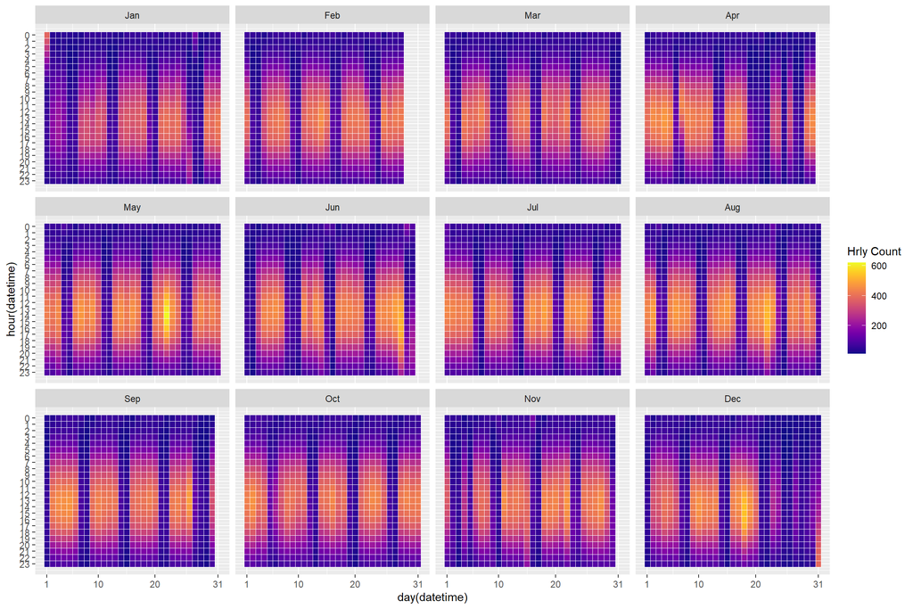

```r
## Plot heatmap
wav.data %>%
  ggplot(aes(x=day(datetime),y=hour(datetime),fill=S3)) +
  geom_tile(color="white", size=0.1) +
  scale_fill_viridis(name="Hrly Count" ,option ="C") +
  facet_wrap(~month(datetime, label = TRUE)) +
  scale_y_continuous(trans = "reverse", breaks = unique(hour(wav.data$datetime))) +
  scale_x_continuous(breaks =c(1,10,20,31))
```

Trying to understand the correlation between the results.

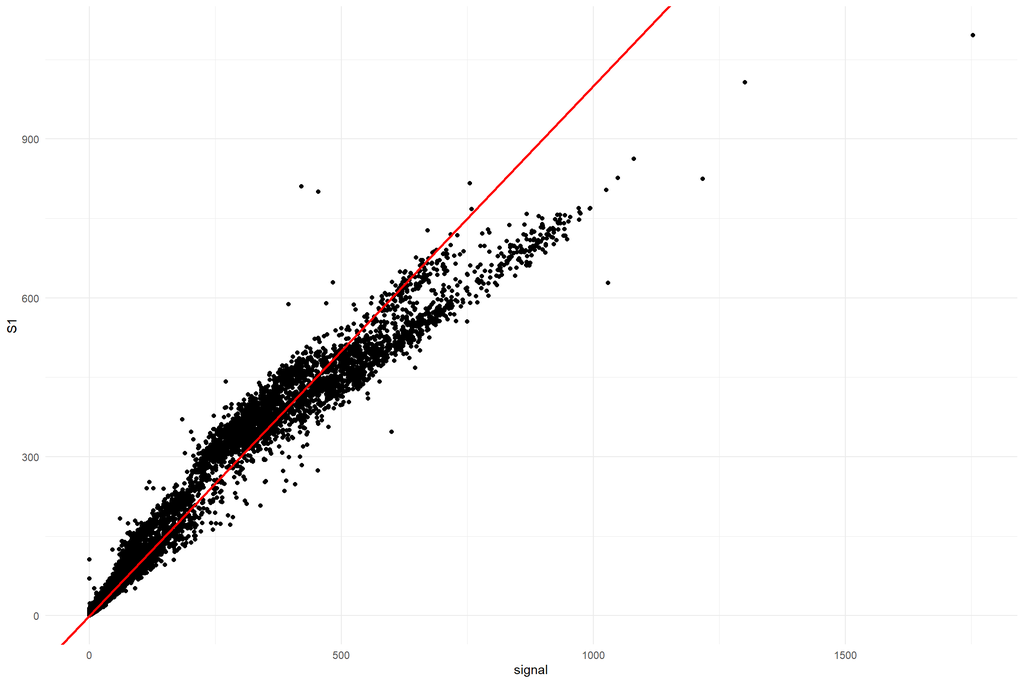

```r
ggplot(wav.data, aes(x=signal, y=S1)) +
  geom_point() +
  geom_abline(slope=1, intercept = 0, colour="red", size=1.0) +
  theme_minimal()
```

### 1.2.3 Outliers Analysis

[figure not shown]

```r
outlier <- function(df, varname){
  thresh1 <- mean(df[[varname]]) - 2 * sd(df[[varname]])
  thresh2 <- mean(df[[varname]]) + 2 * sd(df[[varname]])

  ggplot(df) +
    geom_line(aes(x=datetime, y=varname)) +
    geom_point(aes(x=datetime, y=varname,
                    colour = (varname > thresh1 & varname < thresh2))) +
    theme_minimal()
}

outlier(wav.data, "signal")
```

## 1.3 Variogram-Kriging Analysis

There two tutorials on these pages ([tutorial1](https://rpubs.com/nabilabd/118172), [tutorial2](https://rpubs.com/nabilabd/134781))